# CAPITAL BIKESHARE DATA ANALYSIS

Data Pandas

2025-03-19

# 1 **Introduction**

Bikeshare programs play a vital role in urban transportation, offering a sustainable and cost-effective mode of transportation. However, to maximize their efficiency, it is crucial to understand how, when, and where people use these services. In this study, we analyze Capital Bikeshare usage patterns by examining ride frequency, station popularity, and overall demand trends. Our analysis includes an in-depth look at hourly and daily ride patterns, helping to identify peak usage times and understand how factors like weekdays vs. weekends influence ridership. Additionally, we explore seasonal trends, trip durations, and user behavior to provide a comprehensive data-driven assessment. These insights can help optimize bike distribution, improve station availability, and ensure that the system effectively meets the needs of the community. By leveraging data, we aim to support informed decision-making and enhance the efficiency of the Capital Bikeshare program.

# 2 **Dataset**

The dataset used in this analysis contains Capital Bikeshare trip data for January 2025, covering the first month of the year. It includes information on over 280,000 rides, capturing details such as start and end stations, trip duration, timestamps, and user types. This data is publicly available on the Capital Bikeshare (CaBi) website, where historical trip records can be accessed for analysis and research. By leveraging this dataset, we aim to uncover key insights into bikeshare usage patterns and optimize bike distribution across the system.

## 2.1 Lets load the dataset:

We will load rthe dataset and see a few rows.

```r
BikeShare_Data <- data.frame(read.csv("202501-capitalbikeshare-tripdata.csv"))
head(BikeShare_Data, n=5)
```

|  | ride_id | rideable_type | started_at | ended_at | start_station_name | start_station_id | end_station_name | end_station_id | start_lat | start_lng | end_lat | end_lng | member_casual |
| --- | --- | --- | --- | --- | --- | --- | --- | --- | --- | --- | --- | --- | --- |
| 1 | 63DF1EFB0216674C | electric_bike | 2025-01-18 16:14:21.601 | 2025-01-18 16:20:13.231 | 8th & F St NE | 31631 | 1st & K St NE | 31662 | 38.89727 | -76.99475 | 38.90239 | -77.00565 | member |
| 2 | DAD39B0B13A41150 | electric_bike | 2025-01-29 20:36:00.571 | 2025-01-29 20:39:58.943 | Massachusetts Ave & Dupont Circle NW | 31200 | Columbia Rd & Belmont St NW | 31113 | 38.91010 | -77.04440 | 38.92067 | -77.04368 | member |
| 3 | F96FA218286196EC | electric_bike | 2025-01-03 12:17:52.054 | 2025-01-03 12:22:55.910 | Columbia Rd & Belmont St NW | 31113 | Park Rd & Holmead Pl NW | 31602 | 38.92067 | -77.04368 | 38.93080 | -77.03150 | member |
| 4 | 50367789F635AD37 | classic_bike | 2025-01-30 17:34:47.539 | 2025-01-30 17:49:29.391 | New Hampshire Ave & 24th St NW | 31275 | 7th St & Florida Ave NW | 31109 | 38.90176 | -77.05108 | 38.91614 | -77.02200 | member |
| 5 | 074F88EFE803A53C | electric_bike | 2025-01-31 09:37:39.965 | 2025-01-31 09:44:00.375 | Massachusetts Ave & Dupont Circle NW | 31200 | 23rd & E St NW | 31260 | 38.91010 | -77.04440 | 38.89610 | -77.04988 | member |

Let’s see the structure and summary of the variables in the dataset to get an idea about it.

```
## 'data.frame':    285731 obs. of  13 variables:
##  $ ride_id           : chr  "63DF1EFB0216674C" "DAD39B0B13A41150" "F96FA218286196EC" "50367789F635AD37" ...
##  $ rideable_type     : chr  "electric_bike" "electric_bike" "electric_bike" "classic_bike" ...
##  $ started_at        : chr  "2025-01-18 16:14:21.601" "2025-01-29 20:36:00.571" "2025-01-03 12:17:52.054" "2025-01-30 17:34:47.539" ...
##  $ ended_at          : chr  "2025-01-18 16:20:13.231" "2025-01-29 20:39:58.943" "2025-01-03 12:22:55.910" "2025-01-30 17:49:29.391" ...
##  $ start_station_name: chr  "8th & F St NE" "Massachusetts Ave & Dupont Circle NW" "Columbia Rd & Belmont St NW" "New Hampshire Ave & 24th St NW" ...
##  $ start_station_id  : int  31631 31200 31113 31275 31200 31631 31631 31631 31200 31200 ...
##  $ end_station_name  : chr  "1st & K St NE" "Columbia Rd & Belmont St NW" "Park Rd & Holmead Pl NW" "7th St & Florida Ave NW" ...
##  $ end_station_id    : int  31662 31113 31602 31109 31260 31218 31218 31631 31223 31223 ...
##  $ start_lat         : num  38.9 38.9 38.9 38.9 38.9 ...
##  $ start_lng         : num  -77 -77 -77 -77.1 -77 ...
##  $ end_lat           : num  38.9 38.9 38.9 38.9 38.9 ...
##  $ end_lng           : num  -77 -77 -77 -77 -77 ...
##  $ member_casual     : chr  "member" "member" "member" "member" ...
```

```
##    ride_id          rideable_type       started_at          ended_at
##  Length:285731      Length:285731      Length:285731      Length:285731
##  Class :character   Class :character   Class :character   Class :character
##  Mode  :character   Mode  :character   Mode  :character   Mode  :character
##
##
##
##
##  start_station_name start_station_id end_station_name   end_station_id
##  Length:285731      Min.   :30200    Length:285731      Min.   :30200
##  Class :character   1st Qu.:31203    Class :character   1st Qu.:31208
##  Mode  :character   Median :31291    Mode  :character   Median :31289
##                     Mean   :31376                       Mean   :31376
##                     3rd Qu.:31606                       3rd Qu.:31609
##                     Max.   :33200                       Max.   :33200
##                     NA's   :88122                       NA's   :91217
##    start_lat       start_lng         end_lat         end_lng
##  Min.   :38.76   Min.   :-77.39   Min.   :38.75   Min.   :-77.39
##  1st Qu.:38.90   1st Qu.:-77.04   1st Qu.:38.90   1st Qu.:-77.04
##  Median :38.91   Median :-77.03   Median :38.91   Median :-77.03
##  Mean   :38.91   Mean   :-77.03   Mean   :38.91   Mean   :-77.03
##  3rd Qu.:38.92   3rd Qu.:-77.01   3rd Qu.:38.92   3rd Qu.:-77.01
##  Max.   :39.13   Max.   :-76.83   Max.   :39.24   Max.   :-76.65
##                                   NA's   :183     NA's   :183
##  member_casual
##  Length:285731
##  Class :character
##  Mode  :character
##
##
##
##
```

# 3 **Data Preprocessing**

Raw data is often not in the ideal format for analysis, and the Capital Bikeshare dataset is no exception. To ensure meaningful insights, we must clean, transform, and structure the data to align with our analytical needs.

## 3.1 Removing Unwanted Columns and Converting Data Types

```r
BikeShare_Data$end_lat <- NULL
BikeShare_Data$end_lng <- NULL
BikeShare_Data$start_lat <- NULL
BikeShare_Data$start_lng <- NULL
BikeShare_Data$member_casual <- as.factor(BikeShare_Data$member_casual)
str(BikeShare_Data)
```

```
## 'data.frame':    285731 obs. of  9 variables:
##  $ ride_id           : chr  "63DF1EFB0216674C" "DAD39B0B13A41150" "F96FA218286196EC" "50367789F635AD37" ...
##  $ rideable_type     : chr  "electric_bike" "electric_bike" "electric_bike" "classic_bike" ...
##  $ started_at        : chr  "2025-01-18 16:14:21.601" "2025-01-29 20:36:00.571" "2025-01-03 12:17:52.054" "2025-01-30 17:34:47.539" ...
##  $ ended_at          : chr  "2025-01-18 16:20:13.231" "2025-01-29 20:39:58.943" "2025-01-03 12:22:55.910" "2025-01-30 17:49:29.391" ...
##  $ start_station_name: chr  "8th & F St NE" "Massachusetts Ave & Dupont Circle NW" "Columbia Rd & Belmont St NW" "New Hampshire Ave & 24th St NW" ...
##  $ start_station_id  : int  31631 31200 31113 31275 31200 31631 31631 31631 31200 31200 ...
##  $ end_station_name  : chr  "1st & K St NE" "Columbia Rd & Belmont St NW" "Park Rd & Holmead Pl NW" "7th St & Florida Ave NW" ...
##  $ end_station_id    : int  31662 31113 31602 31109 31260 31218 31218 31631 31223 31223 ...
##  $ member_casual     : Factor w/ 2 levels "casual","member": 2 2 2 2 2 2 2 2 2 2 ...
```

## 3.2 Handling Duplicates

There might be some duplicate values in the data. These duplicate values will always be a problem in our analysis. Let’s remove them.

```r
duplicates_count <- sum(duplicated(BikeShare_Data))
duplicates_count
```

```
## [1] 0
```

There are no duplicate values at all! Capital Bikeshare is maintaining it’s data very accurately.

## 3.3 Handling Missing Values

There will difinately be some rows with a lot of missing values. Since our dataset is huge(280000+), we can remove the missing values. Let’s try to identify them, first.

```r
missing_values <- colSums(is.na(BikeShare_Data))
missing_values
```

```
##            ride_id      rideable_type         started_at           ended_at
##                  0                  0                  0                  0
## start_station_name   start_station_id   end_station_name     end_station_id
##                  0              88122                  0              91217
##      member_casual
##                  0
```

There are many missing values in the columns start_station_id, end_station_id. Since the start station and end station details are crucial for our analysis, its better if we remove the rows where the start station and end station are missing.

```r
BikeShare_Data <- BikeShare_Data[!is.na(BikeShare_Data$start_station_id) &
                                 !is.na(BikeShare_Data$end_station_id), ]
colSums(is.na(BikeShare_Data))
```

```
##            ride_id      rideable_type         started_at           ended_at
##                  0                  0                  0                  0
## start_station_name   start_station_id   end_station_name     end_station_id
##                  0                  0                  0                  0
##      member_casual
##                  0
```

## 3.4 Filtering Rides

There are a few rides which started in 31st Dec 2024 but ended on 1st Jan 2025. We will remove those rows and then put them in an order according to the time they were started at.

```r
BikeShare_Data <- BikeShare_Data[BikeShare_Data$started_at >= "2025-01-01", ]
BikeShare_Data$started_at <- as.POSIXct(BikeShare_Data$started_at)
BikeShare_Data$ended_at <- as.POSIXct(BikeShare_Data$ended_at)

BikeShare_Data <- BikeShare_Data[order(BikeShare_Data$started_at), ]
nrow(BikeShare_Data)
```

```
## [1] 166757
```

## 3.5 Removing Outliers

We will create a new variable to calculate the trip duration and then filter out the ouliers.

```r
BikeShare_Data$trip_duration <- as.numeric(difftime(BikeShare_Data$ended_at,
                                                    BikeShare_Data$started_at,
                                                    units = "mins"))

BikeShare_Data$hour_of_day <- format(BikeShare_Data$started_at, "%H")

BikeShare_Data$day_of_week <- weekdays(BikeShare_Data$started_at)

BikeShare_Data$day_of_week <- factor(BikeShare_Data$day_of_week,
                                     levels = c("Monday", "Tuesday", "Wednesday",
                                                "Thursday", "Friday", "Saturday", "Sunday"),
                                     ordered = TRUE)

BikeShare_Data <- BikeShare_Data[BikeShare_Data$trip_duration > 0 & BikeShare_Data$trip_duration < 720,]

head(BikeShare_Data)
```

|  | ride_id | rideable_type | started_at | ended_at | start_station_name | start_station_id | end_station_name | end_station_id | member_casual | trip_duration | hour_of_day | day_of_week |
| --- | --- | --- | --- | --- | --- | --- | --- | --- | --- | --- | --- | --- |
| 40025 | A4BB8837C2E0E1FC | electric_bike | 2025-01-01 00:01:43.825 | 2025-01-01 00:17:06.490 | 10th & U St NW | 31111 | 2nd St & Seaton Pl NE | 31522 | casual | 15.377767 | 00 | Wednesday |
| 67191 | 9284CD0225E109C1 | electric_bike | 2025-01-01 00:01:45.608 | 2025-01-01 00:10:32.394 | Connecticut Ave & R St NW | 31299 | 7th & R St NW / Shaw Library | 31245 | member | 8.779767 | 00 | Wednesday |
| 85632 | FC4851D498B0C836 | classic_bike | 2025-01-01 00:03:15.644 | 2025-01-01 00:06:57.125 | 12th St & New York Ave NW | 31670 | 7th & K St NW | 31653 | member | 3.691350 | 00 | Wednesday |
| 113301 | 84ED5655F4FFD5F4 | classic_bike | 2025-01-01 00:03:18.546 | 2025-01-01 00:22:00.443 | 14th & Newton St NW | 31649 | 15th St & New York Ave NW | 31222 | member | 18.698283 | 00 | Wednesday |
| 174783 | 7A852D99C535BF37 | electric_bike | 2025-01-01 00:05:51.368 | 2025-01-01 00:06:08.690 | 11th & Kenyon St NW | 31102 | 11th & Kenyon St NW | 31102 | casual | 0.288700 | 00 | Wednesday |
| 165588 | EA4B796FDB2BC0E5 | electric_bike | 2025-01-01 00:06:05.742 | 2025-01-01 00:28:34.217 | 15th St & Constitution Ave NW | 31321 | Massachusetts Ave & Dupont Circle NW | 31200 | member | 22.474600 | 00 | Wednesday |

# 4 **Exploratory Data Analysis**

EDA is an important step before we move into advanced analysis. Through visualizations and summary statistics, EDA allows us to identify key relationships, trends, and potential areas of improvement. By performing EDA on the Capital Bikeshare dataset, we can gain insights into ride patterns, peak usage times, and station popularity, enabling data-driven decision-making.

## 4.1 Histograms

We’ll start with some simple histograms to get to know our variables clearly.

### 4.1.1 Rideable type

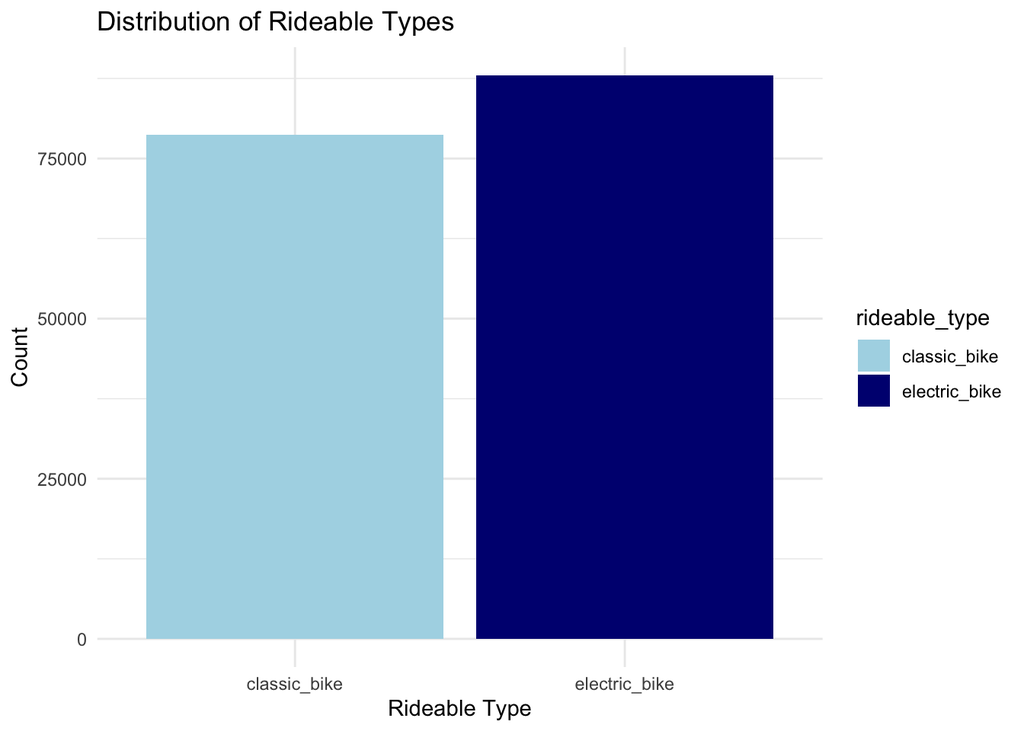

This shows us that Ebikes were more popular than classic bikes.

### 4.1.2 Day of the week

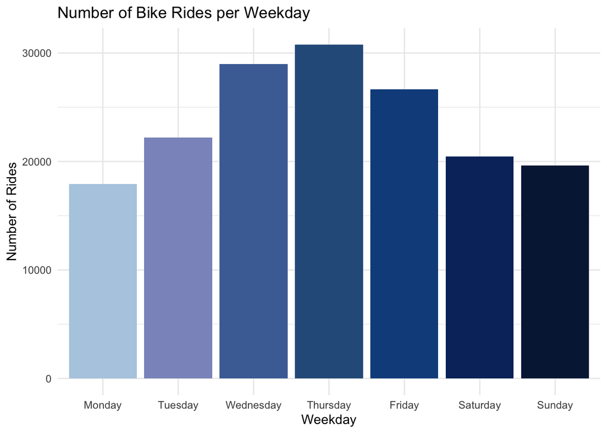

This shows us that bike rides peak on **Thursday**. They are very similar for the weekend days of Saturday and Sunday. Monday is the least popular day for BikeShare rides.

### 4.1.3 Hour of the day

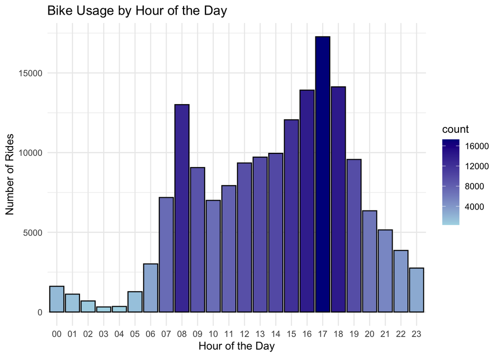

This shows us the rush hour spikes at 8AM and 5PM, when BikeShare users are likely commuting.

If our hypothesis that commuting to work is what is driving the spikes at those times, we should see a difference between weekday and weekend usage.

### 4.1.4 Weekday/Weekends

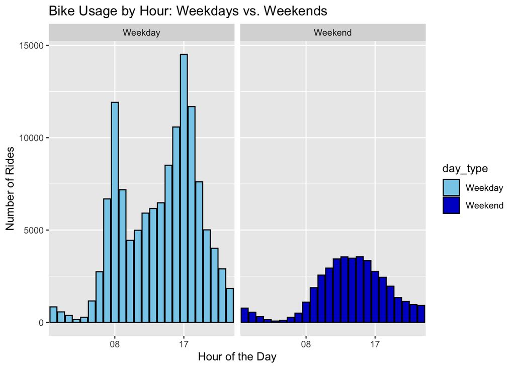

[output not shown]

[output cut: 240 more lines]

[output not shown]

We can clearly the see difference in scale but it’s hard to interpret. Let’s adjust it to highlight where the biggest differences in usage per hour on weekdays vs. weekends is.

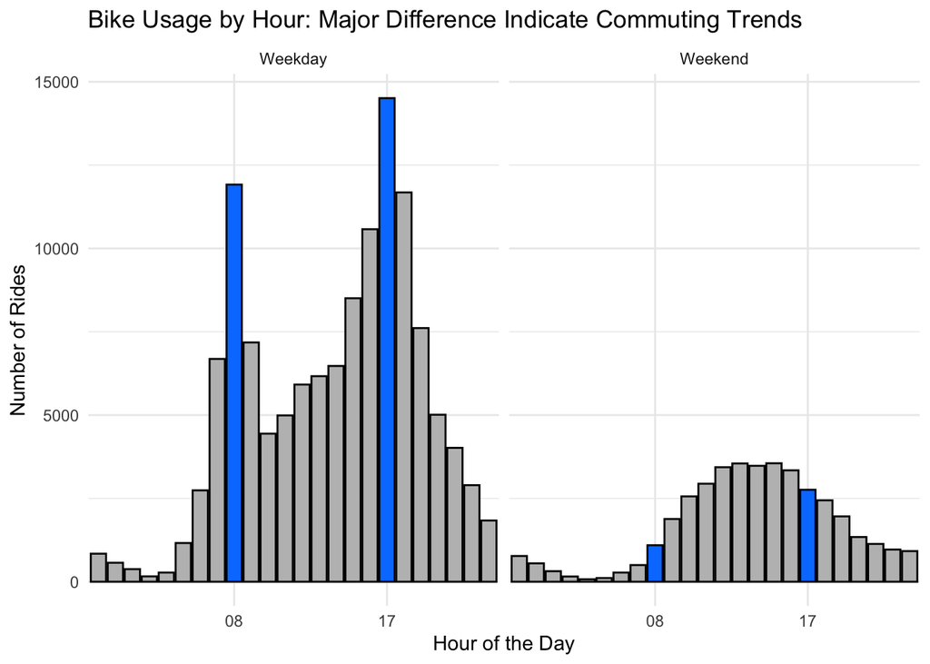

Much better! This graph clearly shows the distinction between ridership during peak commute times on weekday vs. weekends.

| day_of_week | hour_of_day | num_rides |
| --- | --- | --- |
| Monday | 17 | 2100 |
| Tuesday | 17 | 2811 |
| Wednesday | 17 | 3228 |
| Thursday | 17 | 3750 |
| Friday | 17 | 2620 |
| Saturday | 17 | 1548 |
| Sunday | 17 | 1212 |

We can also look at the difference in terms of averages.

| day_type | avg_rides |
| --- | --- |
| Weekday | 25308.2 |
| Weekend | 20060.0 |

## 4.2 Popular Stations

We are also interested in which locations are the most popular. Since we have two location variables, start_station_name and end_station_name, let’s start by looking at them individually.

### 4.2.1 Most Popular Start Stations

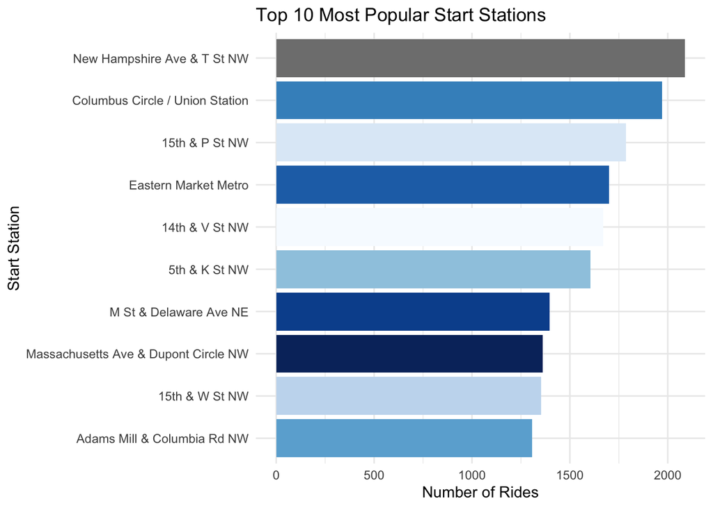

### 4.2.2 Most Popular End Stations

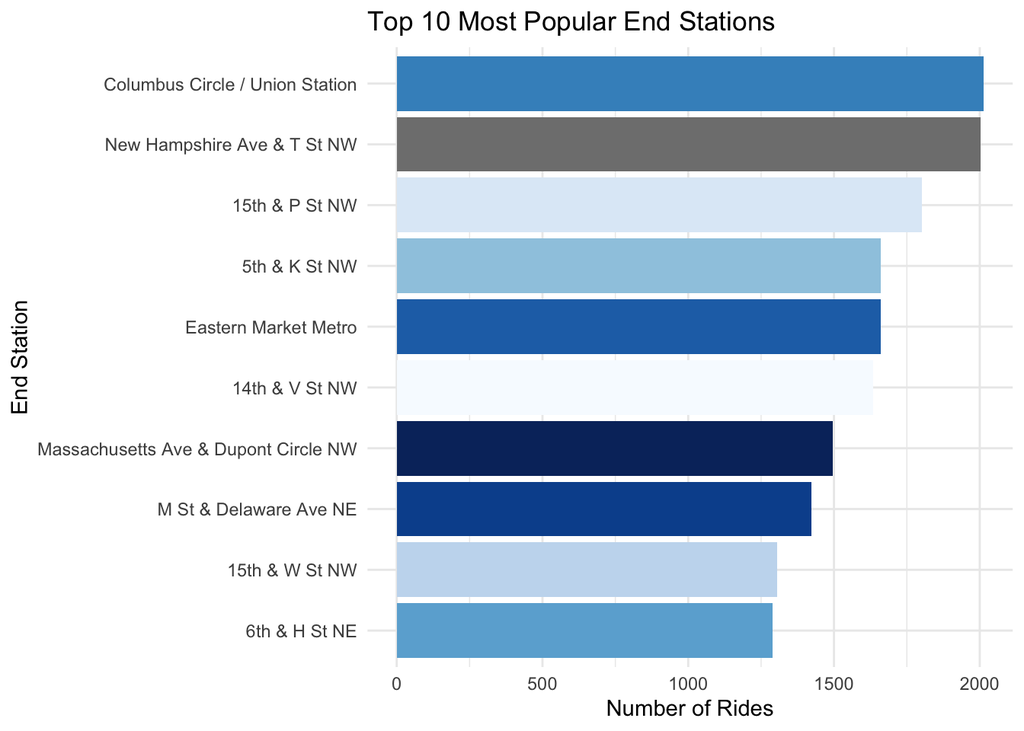

### 4.2.3 Stations with most Traffic

Now we’ll combine them to see which stations get the most overall traffic.

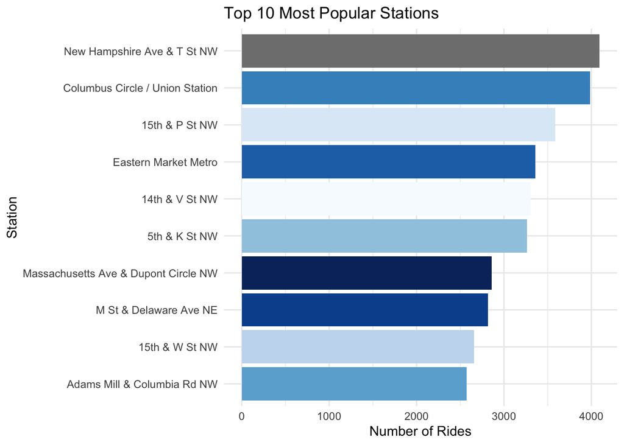

```r
#plotting most popular stations by combined start and stop measure.
combined_station_data <- BikeShare_Data %>%
  gather(key = "station_type", value = "station_name", start_station_name, end_station_name) %>%
  count(station_name, sort = TRUE) %>%
  top_n(10, n)  # Top 10 stations

# Plot Combined Start and End Stations
ggplot(combined_station_data, aes(x = reorder(station_name, n), y = n, fill = station_name)) +
  geom_bar(stat = "identity") +
  coord_flip() +
  labs(title = "Top 10 Most Popular Stations",
       x = "Station",
       y = "Number of Rides") +
   guides(fill = "none") +
  theme_minimal() +
  scale_fill_manual(values = scales::brewer_pal(palette = "Blues")(10))
```

## 4.3 Least Popular Stations

We got to know the popular stations. Similarly, we will see what are the least used stations. Since we have two location variables, start_station_name and end_station_name, let’s start by looking at them individually.

### 4.3.1 Least popular start stations

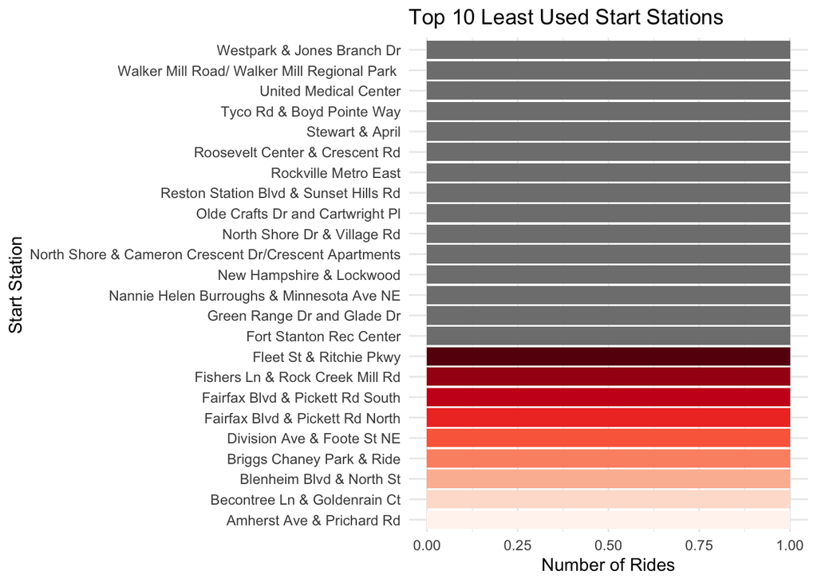

```r
ggplot(least_start_station_counts, aes(x = reorder(start_station_name, n), y = n, fill = start_station_name)) +
  geom_bar(stat = "identity") +
  coord_flip() +
  labs(title = "Top 10 Least Used Start Stations",
       x = "Start Station",
       y = "Number of Rides") +
  guides(fill = "none") +
  theme_minimal() +
  scale_fill_manual(values = scales::brewer_pal(palette = "Reds")(24))
```

We are getting more than 10 values in the graph because there are some stations with same number of rides.

### 4.3.2 Least Popular end stations

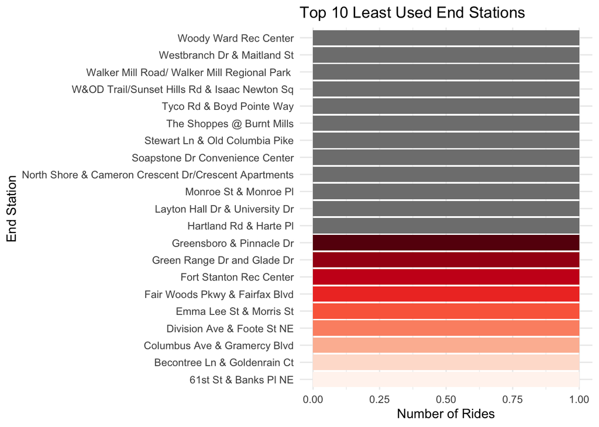

```r
ggplot(least_end_station_counts, aes(x = reorder(end_station_name, n), y = n, fill = end_station_name)) +
  geom_bar(stat = "identity") +
  coord_flip() +
  labs(title = "Top 10 Least Used End Stations",
       x = "End Station",
       y = "Number of Rides") +
  guides(fill = "none") +
  theme_minimal() +
  scale_fill_manual(values = scales::brewer_pal(palette = "Reds")(24))
```

The same issue is happening here, there are a lot of stations with same number of rides. Hence, we are getting more than 10 values.

### 4.3.3 Stations with least traffic

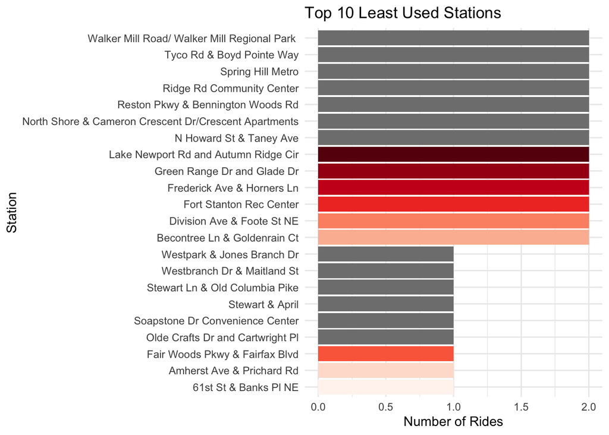

```r
# Finding least popular stations by combined start and stop measure
least_combined_station_data <- BikeShare_Data %>%
  gather(key = "station_type", value = "station_name", start_station_name, end_station_name) %>%
  count(station_name, sort = TRUE) %>%
  top_n(-10, n)  # Get bottom 10 stations

# Plot Combined Least Used Start and End Stations
ggplot(least_combined_station_data, aes(x = reorder(station_name, n), y = n, fill = station_name)) +
  geom_bar(stat = "identity") +
  coord_flip() +
  labs(title = "Top 10 Least Used Stations",
       x = "Station",
       y = "Number of Rides") +
  guides(fill = "none") +
  theme_minimal() +
  scale_fill_manual(values = scales::brewer_pal(palette = "Reds")(24))
```

We can clearly see that some stations have less than 2 rides!! While the popular stations have thousands of rides,

## 4.4 Normality tests

### 4.4.1 Analyzing Ride Start and End Times

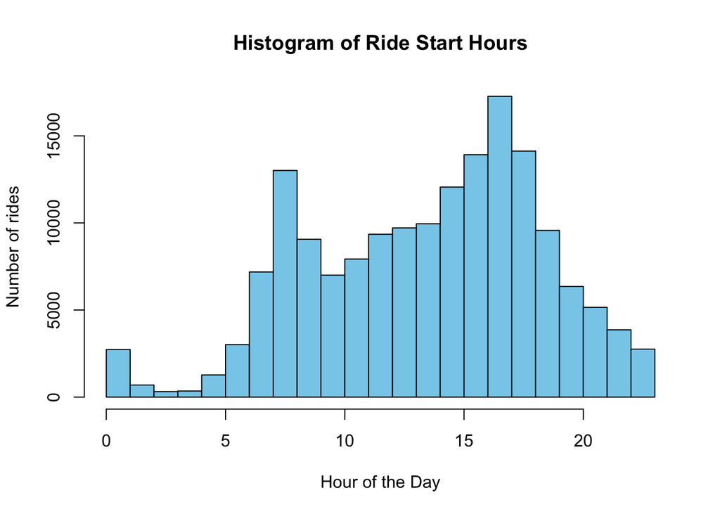

```r
hist(as.numeric(BikeShare_Data$hour_of_day), breaks = 24, main = "Histogram of Ride Start Hours", xlab = "Hour of the Day", ylab = "Number of rides", col = "skyblue", border = "black")
```

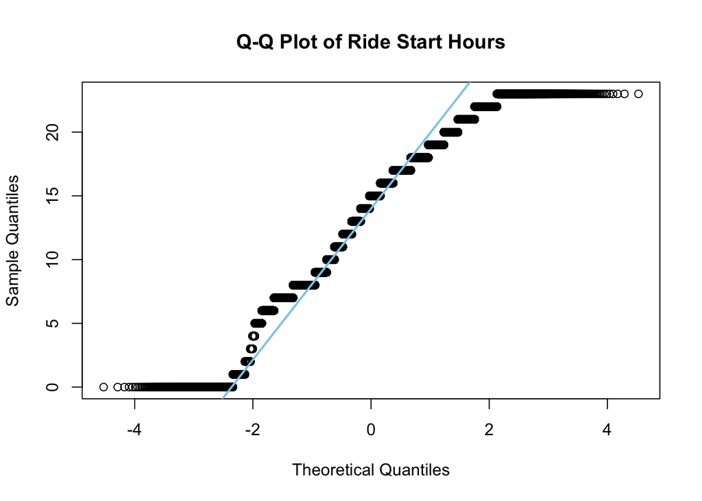

```r
# Q-Q plot for Ride Start Hours
qqnorm(as.numeric(BikeShare_Data$hour_of_day), main = "Q-Q Plot of Ride Start Hours")
qqline(as.numeric(BikeShare_Data$hour_of_day), col = "skyblue", lwd = 2)
```

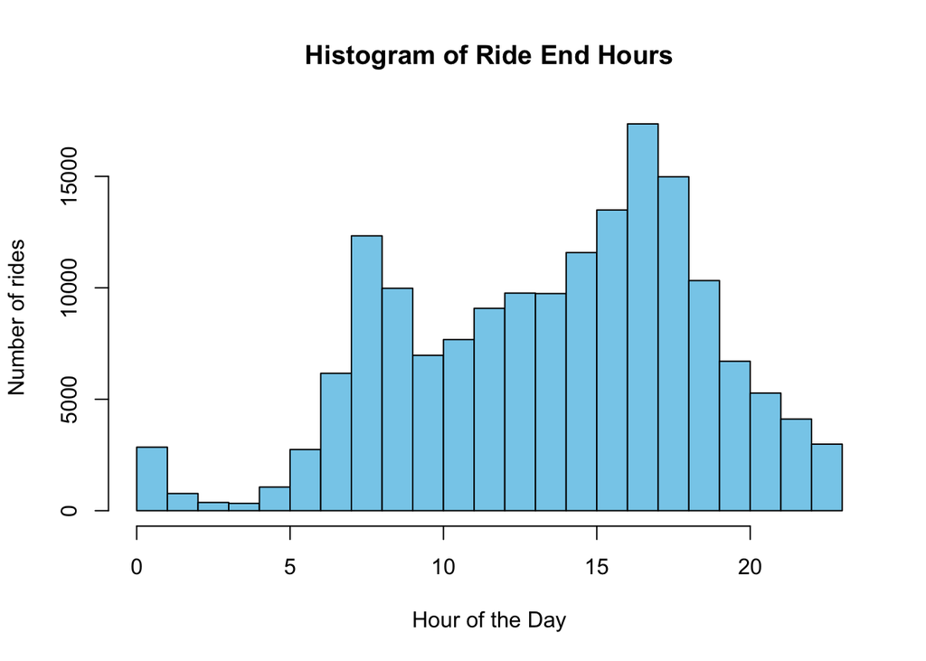

```r
ride_end_hours = as.numeric(format(BikeShare_Data$ended_at, "%H"))
hist(ride_end_hours, breaks = 24, main = "Histogram of Ride End Hours", xlab = "Hour of the Day", ylab = "Number of rides", col = "skyblue", border = "black")
```

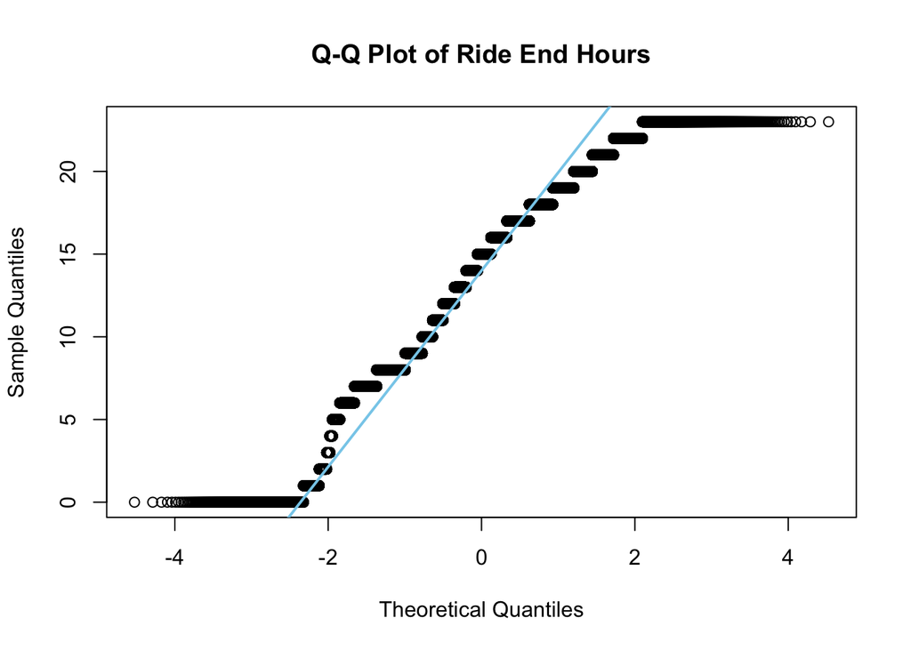

```r
# Q-Q plot for Ride End Hours
qqnorm(ride_end_hours, main = "Q-Q Plot of Ride End Hours")
qqline(ride_end_hours, col = "skyblue", lwd = 2)
```

### 4.4.2 Normality tests using Shapiro-Wilk & Anderson-Darling

```r
#Normality tests
shapiro.test(sample(as.numeric(BikeShare_Data$hour_of_day), 5000))
```

```
##
##  Shapiro-Wilk normality test
##
## data:  sample(as.numeric(BikeShare_Data$hour_of_day), 5000)
## W = 0.97075, p-value < 2.2e-16
```

```r
library(nortest)
ad_test <- ad.test(as.numeric(BikeShare_Data$hour_of_day))
ad_test
```

```
##
##  Anderson-Darling normality test
##
## data:  as.numeric(BikeShare_Data$hour_of_day)
## A = 1535.7, p-value < 2.2e-16
```

It is evident from the histograms and Q-Q plots of Ride Start/End Hours that the distribution is not normal and is left skewed. Also, when we test normality using Shapiro test, a p-value < 2.2e−16, indicates a strong evidence against normality.Similarly, the Anderson-Darling test shows a p-value < 2.2e−16, further confirming significant deviation from a normal distribution.

### 4.4.3 Trip Duration Distribution Analysis

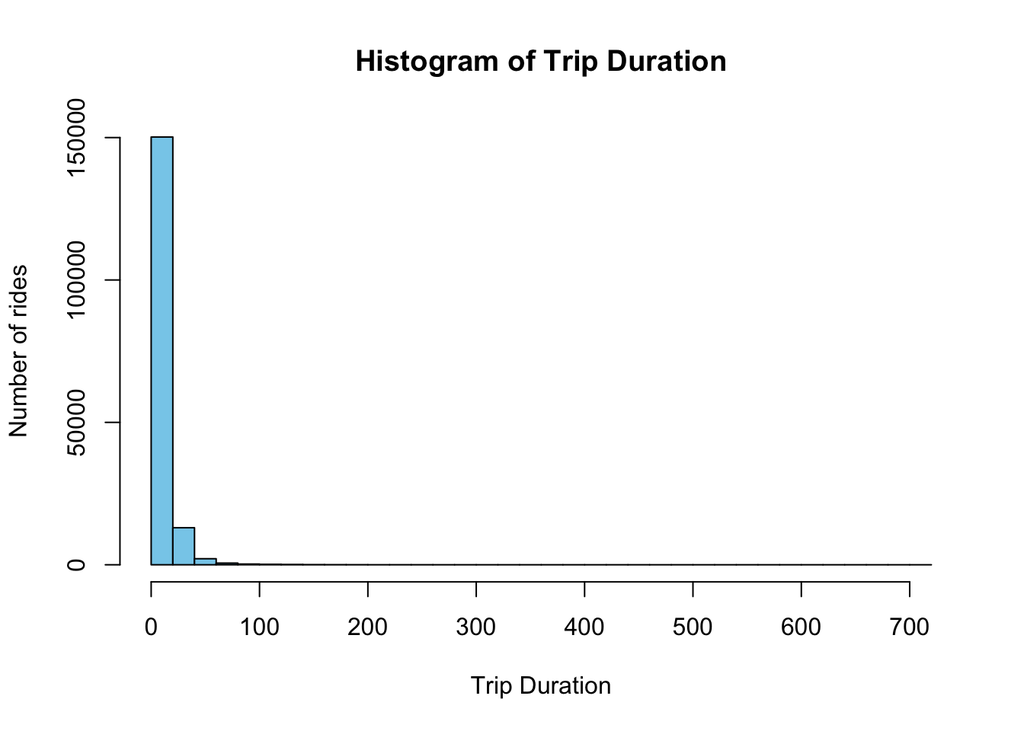

```r
hist(BikeShare_Data$trip_duration, breaks = 30, main = "Histogram of Trip Duration", xlab = "Trip Duration",ylab = "Number of rides", col = "skyblue", border = "black")
```

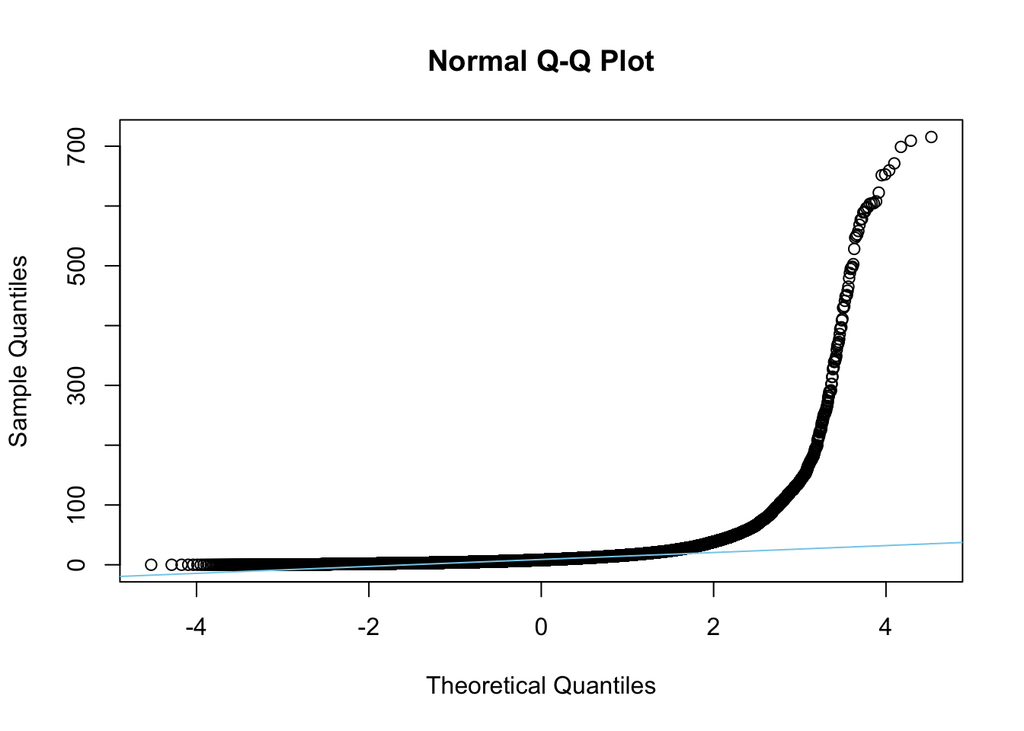

```r
qqnorm(BikeShare_Data$trip_duration)
qqline(BikeShare_Data$trip_duration, col = "skyblue")
```

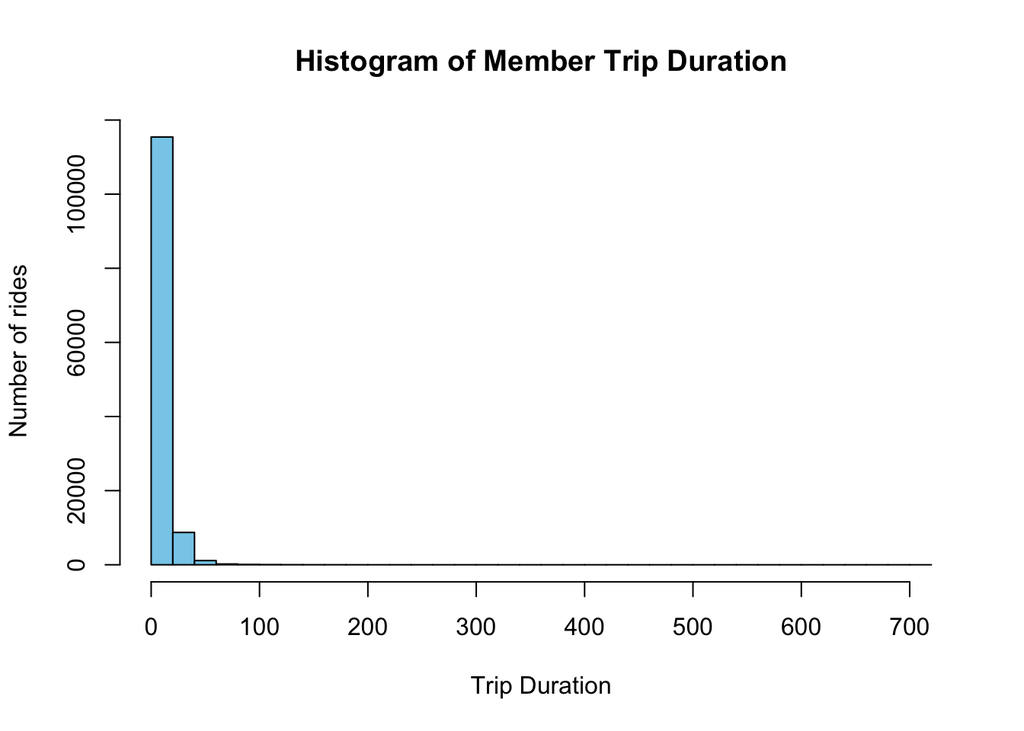

```r
member_ride_duration = BikeShare_Data$trip_duration[BikeShare_Data$member_casual == "member"]
hist(member_ride_duration, breaks = 30, main = "Histogram of Member Trip Duration", xlab = "Trip Duration",ylab = "Number of rides", col = "skyblue", border = "black")
```

[figure not shown]

```r
casual_ride_duration = BikeShare_Data$trip_duration[BikeShare_Data$member_casual == "casual"]
hist(member_ride_duration, breaks = 30, main = "Histogram of Casual Trip Duration", xlab = "Trip Duration",ylab = "Number of rides", col = "skyblue", border = "black")
```

```r
#Normality tests
ad_test <- ad.test(BikeShare_Data$trip_duration)
ad_test
```

```
##
##  Anderson-Darling normality test
##
## data:  BikeShare_Data$trip_duration
## A = 19955, p-value < 2.2e-16
```

### 4.4.4 Measuring Variability in Trip Duration

Let’s explore the variance or spread of our dataset using standard deviation and variance measures. Trip duration is a good variable for us to look at in order to understand variation in how customers are using the BikeShare.

```r
sd.trip_duration <- sd(BikeShare_Data$trip_duration)
mean.trip_duration <- mean(BikeShare_Data$trip_duration)

print(mean.trip_duration)
```

```
## [1] 11.03512
```

```r
print(sd.trip_duration)
```

```
## [1] 14.9033
```

The average trip length is 11 minutes, with a standard deviation of 14.9 minutes. That indicates a lot of variance in our dataset!

Let’s also run the variance, mean, and sd directly.

```r
var(BikeShare_Data$trip_duration, na.rm = T)
```

```
## [1] 222.1084
```

```r
mean(BikeShare_Data$trip_duration, na.rm = T)
```

```
## [1] 11.03512
```

```r
sd(BikeShare_Data$trip_duration, na.rm = T)
```

```
## [1] 14.9033
```

Our variance and SD are large, indicating that we have both short and long trips in our dataset compared to the mean. Let’s check the range.

```r
range(BikeShare_Data$trip_duration, na.rm = TRUE)
```

```
## [1]   0.0199 715.4107
```

Yep, that’s a large range! We probably have some outliers that are impacting that, so let’s also check the interquartile range.

```r
IQR(BikeShare_Data$trip_duration, na.rm = TRUE)
```

```
## [1] 7.861033
```

Much smaller! That indicates the outliers are having a strong impact. Let’s visualize this with a boxplot. We’ll check to make sure our data is suitable for that visualization first.

```r
summary(BikeShare_Data$trip_duration)
```

```
##     Min.  1st Qu.   Median     Mean  3rd Qu.     Max.
##   0.0199   5.0688   8.1253  11.0351  12.9298 715.4107
```

```r
BikeShare_Data <- na.omit(BikeShare_Data)
```

Because the range is so wide, we probably need to remove the true outliers in order to have a visualization that makes sense. We’ll remove the upper and lower bounds from our IQR in order to do that.

### 4.4.5 Visualizing Trip Duration Without Outliers

```r
Q1 <- quantile(BikeShare_Data$trip_duration, 0.25, na.rm = TRUE)
Q3 <- quantile(BikeShare_Data$trip_duration, 0.75, na.rm = TRUE)
IQR <- Q3 - Q1

#Defining the outlier bounds
lower_bound <- Q1 - 1.5 * IQR
upper_bound <- Q3 + 1.5 * IQR

# Filter out the observations where trip_duration is outside the upper and lower bounds as we've defined them
BikeShare_Data_no_outliers <- BikeShare_Data %>%
  filter(trip_duration >= lower_bound & trip_duration <= upper_bound)

#Check the new data
summary(BikeShare_Data_no_outliers$trip_duration)
```

```
##    Min. 1st Qu.  Median    Mean 3rd Qu.    Max.
##  0.0199  4.9012  7.7043  8.8242 11.7734 24.7201
```

This will be much easier to interpret.

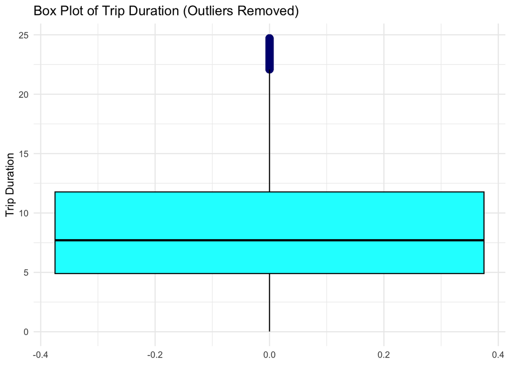

```r
# Boxplot after removing outliers
ggplot(BikeShare_Data_no_outliers, aes(y = trip_duration)) +
  geom_boxplot(
    outlier.colour = "navy",  # Color outliers in red
    outlier.size = 3,        # Size of the outliers
    fill = "#00FFFF",        # Fill the box with cyan
    color = "black"          # Border color of the box
  ) +
  labs(title = "Box Plot of Trip Duration (Outliers Removed)",
       y = "Trip Duration") +
  theme_minimal()
```

# 5 **Inferential Statistics**

Inferential statistics allow us to make conclusions about a population based on a sample of data. Unlike Exploratory Data Analysis (EDA), which focuses on summarizing and visualizing data, inferential statistics use techniques like confidence intervals, Statistical tests and regression analysis to draw insights beyond the observed dataset. This helps in making predictions and generalizations, such as estimating average trip duration for all bikeshare users based on a sample.

## 5.1 Confidence intervals and Z-scores

Now let’s calculate the confidence intervals and z-scores. We chose to conduct the z test instead of the t test because of our large sample size and the fact that we just calculated the standard deviation.

```r
 library(BSDA)  # Load package for z.test()
# Sample size (excluding NA values)
n <- sum(!is.na(BikeShare_Data$trip_duration))

# Compute mean and standard deviation
mean_trip_duration <- mean(BikeShare_Data$trip_duration, na.rm = TRUE)
sd_trip_duration <- sd(BikeShare_Data$trip_duration, na.rm = TRUE)

# Perform z-test assuming a known population standard deviation
ztest95 <- z.test(x = BikeShare_Data$trip_duration, sigma.x = sd_trip_duration)

# Compute the standard error
se_trip_duration <- sd_trip_duration / sqrt(n)

# Extract confidence interval from z.test() result
lower_bound <- ztest95$conf.int[1]
upper_bound <- ztest95$conf.int[2]

# Print results
cat("Mean Trip Duration:", mean_trip_duration, "minutes\n")
```

```
## Mean Trip Duration: 11.03512 minutes
```

```r
cat("Standard Deviation:", sd_trip_duration, "minutes\n")
```

```
## Standard Deviation: 14.9033 minutes
```

```r
cat("Sample Size:", n, "rides\n")
```

```
## Sample Size: 166661 rides
```

```r
cat("95% Confidence Interval: (", lower_bound, ",", upper_bound, ") minutes\n")
```

```
## 95% Confidence Interval: ( 10.96357 , 11.10667 ) minutes
```

```r
# Calculate Z-scores for trip duration
BikeShare_Data$z_score <- (BikeShare_Data$trip_duration - mean_trip_duration) / sd_trip_duration

# Display first few rows with z-scores
head(BikeShare_Data[, c("trip_duration", "z_score")])
```

|  | trip_duration | z_score |
| --- | --- | --- |
| 40025 | 15.377767 | 0.2913885 |
| 67191 | 8.779767 | -0.1513322 |
| 85632 | 3.691350 | -0.4927610 |
| 113301 | 18.698283 | 0.5141926 |
| 174783 | 0.288700 | -0.7210762 |
| 165588 | 22.474600 | 0.7675805 |

Bike-share trips take around 11 minutes on average, which makes sense seeing as bikes are typically used to travel short distances. However, the standard deviation of 14.90 minutes suggests a high amount of variation in trip duration, with some users taking significantly shorter or longer rides.

The confidence interval indicates that we are 95% confident that the mean trip duration falls between 10.96 and 11.11 minutes. This narrow interval means that our estimate is precise.

The prevalence of short trips reinforces the idea that bike-share programs function as a convenient option for brief commutes. However, the high variance in trip duration suggests that some users rely on the service for longer rides. Given this, bike-share companies should consider optimizing bike availability by frequently redistributing bikes to high-traffic stations. Additionally, analyzing z-scores can help identify irregular rides such as abnormally long trips, which may indicate potential issues like technical problems with bike returns.

## 5.2 Correlation test

Now lets see the correlation between the variables trip_duration and hour_of_day (Are longer trips consistently taken at certain times of the day?):

```r
BikeShare_Data$hour_of_day <- as.numeric(BikeShare_Data$hour_of_day)

# Perform correlation test and store results clearly
cor_result <- cor.test(BikeShare_Data$trip_duration, BikeShare_Data$hour_of_day)

# Extracting correlation coefficient and p-value
correlation_coefficient <- cor_result$estimate
cor_pvalue <- cor_result$p.value

cat("Correlation coefficient:", correlation_coefficient, "\n")
```

```
## Correlation coefficient: -0.01582298
```

```r
cat("p-value:", cor_result$p.value, "\n")
```

```
## p-value: 1.047362e-10
```

This correlation test clearly helps us understand whether rides taken at different hours of the day vary systematically in length. A correlation coefficient near 0 and a p-value > 0.05 would suggest no significant correlation between trip duration and hour of day.

## 5.3 ANOVA test

Let’s perform the Anova test between a numerical variable trip_duration and dat_of_week (Does Thursday have significantly longer/shorter trips than Monday?):

```r
anova_result <- aov(trip_duration ~ day_of_week, data = BikeShare_Data)
summary(anova_result)
```

```
##                 Df   Sum Sq Mean Sq F value  Pr(>F)
## day_of_week      6    17313    2886      13 9.4e-15 ***
## Residuals   166654 36999273     222
## ---
## Signif. codes:  0 '***' 0.001 '**' 0.01 '*' 0.05 '.' 0.1 ' ' 1
```

## 5.4 Chi-Squared test

Now let’s perform the chi-squared test on member_casual and rideable_type where both are categorical variables. (Do casual riders prefer electric bikes significantly more than members?):

We need to create a contingency table.

```r
contingency_table <- table(BikeShare_Data$member_casual, BikeShare_Data$rideable_type)

chisq_result <- chisq.test(contingency_table)
chisq_result
```

```
##
##  Pearson's Chi-squared test with Yates' continuity correction
##
## data:  contingency_table
## X-squared = 2561.4, df = 1, p-value < 2.2e-16
```

# 6 **Conclusion**

## 6.1 Our Insights

Our analysis of Capital Bikeshare’s January 2025 trip data provided valuable insights into rider behavior, station usage, and trip patterns. Through exploratory data analysis (EDA), we identified key trends in ride start and end times, trip durations, and user types, which can help optimize the bikeshare system.

From our station analysis, we found that certain stations experience high demand with thousands of riders, while others are underutilized with less that 2 rides in a month. This suggests that redistributing bikes to high-traffic areas could improve efficiency.

Similarly, by analyzing ride start and end times, we observed a left-skewed distribution, indicating peak usage during morning and evening commute hours. The Shapiro-Wilk and Anderson-Darling tests confirmed that ride hours do not follow a normal distribution, which tells that in the peak morning and evening commuter times, bikes should be available.

To understand variability, we analyzed standard deviation, variance, and range, which showed high fluctuations in trip durations. The interquartile range (IQR) method helped us remove outliers, making the data more interpretable. Visualizing the cleaned data with boxplots confirmed the presence of extreme values(trip duration) affecting overall trends.

## 6.2 Final Thoughts

This project highlights the power of data-driven decision-making in urban transportation systems. By leveraging statistical analysis and visualization techniques, we can enhance the efficiency, accessibility, and sustainability of bikeshare programs, ultimately improving the user experience and operational effectiveness of Capital Bikeshare.